# Risk Factor Analysis

## Outcome Variable

**Outcome Variable:** wasted

## Predictor Variables

**Intervention Variable:** fage

**Adjustment Set:**

- arm
- W_mage
- meducyrs
- feducyrs
- W_mhtcm
- W_mwtkg
- W_mbmi
- W_fhtcm
- single
- brthmon
- delta_W_mage
- delta_meducyrs
- delta_feducyrs
- delta_W_mhtcm
- delta_W_mwtkg
- delta_W_mbmi
- delta_W_fhtcm
- delta_single
- delta_brthmon

## Stratifying Variables

The analysis was stratified on these variable(s):

- agecat
- studyid
- country

## Data Summary

| agecat | studyid | country | fage | wasted | n_cell | n |
| --- | --- | --- | --- | --- | --- | --- |
| Birth | COHORTS | GUATEMALA | >=38 | 0 | 165 | 735 |
| Birth | COHORTS | GUATEMALA | >=38 | 1 | 57 | 735 |
| Birth | COHORTS | GUATEMALA | <32 | 0 | 251 | 735 |
| Birth | COHORTS | GUATEMALA | <32 | 1 | 86 | 735 |
| Birth | COHORTS | GUATEMALA | [32-38) | 0 | 132 | 735 |
| Birth | COHORTS | GUATEMALA | [32-38) | 1 | 44 | 735 |
| Birth | COHORTS | PHILIPPINES | >=38 | 0 | 264 | 2797 |
| Birth | COHORTS | PHILIPPINES | >=38 | 1 | 39 | 2797 |
| Birth | COHORTS | PHILIPPINES | <32 | 0 | 1659 | 2797 |
| Birth | COHORTS | PHILIPPINES | <32 | 1 | 322 | 2797 |
| Birth | COHORTS | PHILIPPINES | [32-38) | 0 | 445 | 2797 |
| Birth | COHORTS | PHILIPPINES | [32-38) | 1 | 68 | 2797 |
| Birth | MAL-ED | BANGLADESH | >=38 | 0 | 50 | 128 |
| Birth | MAL-ED | BANGLADESH | >=38 | 1 | 11 | 128 |
| Birth | MAL-ED | BANGLADESH | <32 | 0 | 16 | 128 |
| Birth | MAL-ED | BANGLADESH | <32 | 1 | 7 | 128 |
| Birth | MAL-ED | BANGLADESH | [32-38) | 0 | 39 | 128 |
| Birth | MAL-ED | BANGLADESH | [32-38) | 1 | 5 | 128 |
| Birth | MAL-ED | BRAZIL | >=38 | 0 | 5 | 16 |
| Birth | MAL-ED | BRAZIL | >=38 | 1 | 0 | 16 |
| Birth | MAL-ED | BRAZIL | <32 | 0 | 1 | 16 |
| Birth | MAL-ED | BRAZIL | <32 | 1 | 0 | 16 |
| Birth | MAL-ED | BRAZIL | [32-38) | 0 | 10 | 16 |
| Birth | MAL-ED | BRAZIL | [32-38) | 1 | 0 | 16 |
| Birth | MAL-ED | INDIA | >=38 | 0 | 7 | 25 |
| Birth | MAL-ED | INDIA | >=38 | 1 | 0 | 25 |
| Birth | MAL-ED | INDIA | <32 | 0 | 6 | 25 |
| Birth | MAL-ED | INDIA | <32 | 1 | 2 | 25 |
| Birth | MAL-ED | INDIA | [32-38) | 0 | 7 | 25 |
| Birth | MAL-ED | INDIA | [32-38) | 1 | 3 | 25 |

[output cut: 180 more lines]

The following strata were considered:

- agecat: 24 months, studyid: COHORTS, country: GUATEMALA
- agecat: 24 months, studyid: COHORTS, country: PHILIPPINES
- agecat: 24 months, studyid: LCNI-5, country: MALAWI
- agecat: 24 months, studyid: MAL-ED, country: BANGLADESH
- agecat: 24 months, studyid: MAL-ED, country: BRAZIL
- agecat: 24 months, studyid: MAL-ED, country: INDIA
- agecat: 24 months, studyid: MAL-ED, country: NEPAL
- agecat: 24 months, studyid: MAL-ED, country: PERU
- agecat: 24 months, studyid: MAL-ED, country: SOUTH AFRICA
- agecat: 24 months, studyid: MAL-ED, country: TANZANIA, UNITED REPUBLIC OF
- agecat: 24 months, studyid: PROBIT, country: BELARUS
- agecat: 6 months, studyid: COHORTS, country: GUATEMALA
- agecat: 6 months, studyid: COHORTS, country: PHILIPPINES
- agecat: 6 months, studyid: LCNI-5, country: MALAWI
- agecat: 6 months, studyid: MAL-ED, country: BANGLADESH
- agecat: 6 months, studyid: MAL-ED, country: BRAZIL
- agecat: 6 months, studyid: MAL-ED, country: INDIA
- agecat: 6 months, studyid: MAL-ED, country: NEPAL
- agecat: 6 months, studyid: MAL-ED, country: PERU
- agecat: 6 months, studyid: MAL-ED, country: SOUTH AFRICA
- agecat: 6 months, studyid: MAL-ED, country: TANZANIA, UNITED REPUBLIC OF
- agecat: 6 months, studyid: PROBIT, country: BELARUS
- agecat: 6 months, studyid: SAS-CompFeed, country: INDIA
- agecat: 6 months, studyid: SAS-FoodSuppl, country: INDIA
- agecat: Birth, studyid: COHORTS, country: GUATEMALA
- agecat: Birth, studyid: COHORTS, country: PHILIPPINES
- agecat: Birth, studyid: MAL-ED, country: BANGLADESH
- agecat: Birth, studyid: MAL-ED, country: BRAZIL
- agecat: Birth, studyid: MAL-ED, country: INDIA
- agecat: Birth, studyid: MAL-ED, country: NEPAL
- agecat: Birth, studyid: MAL-ED, country: PERU
- agecat: Birth, studyid: MAL-ED, country: SOUTH AFRICA
- agecat: Birth, studyid: MAL-ED, country: TANZANIA, UNITED REPUBLIC OF
- agecat: Birth, studyid: PROBIT, country: BELARUS
- agecat: Birth, studyid: SAS-CompFeed, country: INDIA

### Dropped Strata

Some strata were dropped due to rare outcomes:

- agecat: Birth, studyid: MAL-ED, country: BRAZIL
- agecat: Birth, studyid: MAL-ED, country: INDIA
- agecat: Birth, studyid: MAL-ED, country: NEPAL
- agecat: Birth, studyid: MAL-ED, country: PERU
- agecat: Birth, studyid: MAL-ED, country: SOUTH AFRICA
- agecat: Birth, studyid: MAL-ED, country: TANZANIA, UNITED REPUBLIC OF
- agecat: 6 months, studyid: LCNI-5, country: MALAWI
- agecat: 6 months, studyid: MAL-ED, country: BANGLADESH
- agecat: 6 months, studyid: MAL-ED, country: BRAZIL
- agecat: 6 months, studyid: MAL-ED, country: INDIA
- agecat: 6 months, studyid: MAL-ED, country: NEPAL
- agecat: 6 months, studyid: MAL-ED, country: PERU
- agecat: 6 months, studyid: MAL-ED, country: SOUTH AFRICA
- agecat: 6 months, studyid: MAL-ED, country: TANZANIA, UNITED REPUBLIC OF
- agecat: 24 months, studyid: LCNI-5, country: MALAWI
- agecat: 24 months, studyid: MAL-ED, country: BANGLADESH
- agecat: 24 months, studyid: MAL-ED, country: BRAZIL
- agecat: 24 months, studyid: MAL-ED, country: INDIA
- agecat: 24 months, studyid: MAL-ED, country: NEPAL
- agecat: 24 months, studyid: MAL-ED, country: PERU
- agecat: 24 months, studyid: MAL-ED, country: SOUTH AFRICA
- agecat: 24 months, studyid: MAL-ED, country: TANZANIA, UNITED REPUBLIC OF
- agecat: 24 months, studyid: PROBIT, country: BELARUS

## Methods Detail

We’re interested in the causal parameters $E[Y_a]$ for all values of $a \in \mathcal{A}$. These parameters represent the mean outcome if, possibly contrary to fact, we intervened to set all units to have $A=a$. Under the randomization and positivity assumptions, these are identified by the statistical parameters $\psi_a=E_W[E_{Y|A,W}(Y|A=a,W)]$. In addition, we’re interested in the mean of $Y$, $E[Y]$ under no intervention (the observed mean). We will estimate these parameters by using SuperLearner to fit the relevant likelihood factors – $E_{Y|A,W}(Y|A=a,W)$ and $p(A=a|W)$, and then updating our likelihood fit using a joint TMLE.

For unadjusted analyses ($W=\{\}$), initial likelihoods were estimated using Lrnr_glm to estimate the simple $E(Y|A)$ and Lrnr_mean to estimate $p(A)$. For adjusted analyses, a small library containing Lrnr_glmnet, Lrnr_xgboost, and Lrnr_mean was used.

Having estimated these parameters, we will then use the delta method to estimate relative risks and attributable risks relative to a prespecified baseline level of $A$.

# Results Detail

## Results Plots

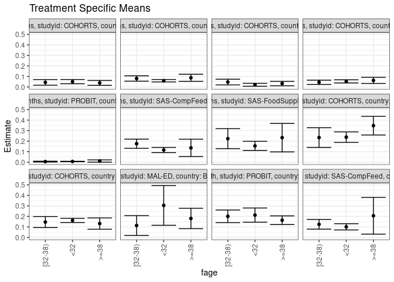

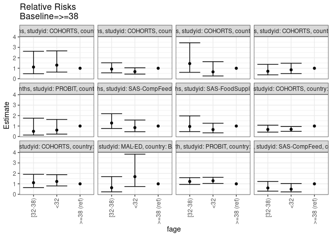

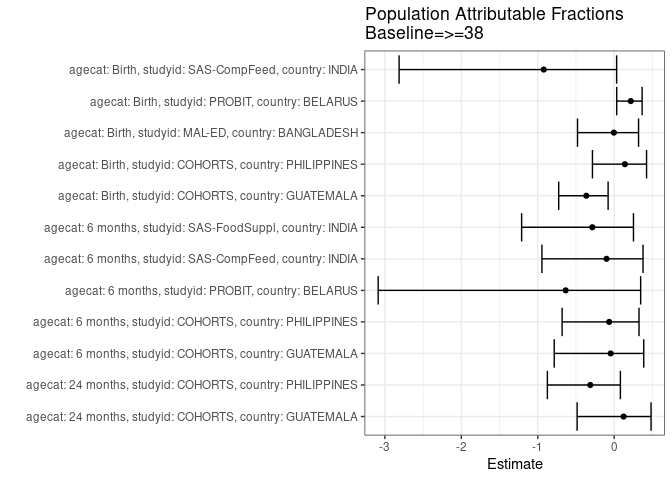

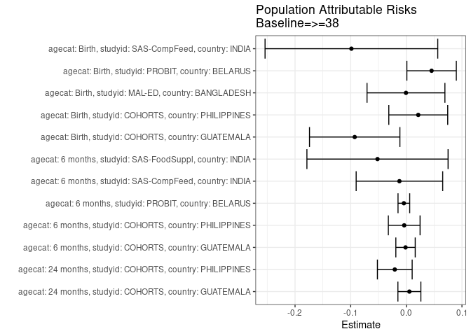

## Results Table

### Parameter: TSM

| agecat | studyid | country | intervention_level | baseline_level | estimate | ci_lower | ci_upper |
| --- | --- | --- | --- | --- | --- | --- | --- |
| Birth | COHORTS | GUATEMALA | >=38 | NA | 0.3472025 | 0.2587006 | 0.4357044 |
| Birth | COHORTS | GUATEMALA | <32 | NA | 0.2380700 | 0.1880182 | 0.2881218 |
| Birth | COHORTS | GUATEMALA | [32-38) | NA | 0.2339420 | 0.1401782 | 0.3277057 |
| Birth | COHORTS | PHILIPPINES | >=38 | NA | 0.1319322 | 0.0781361 | 0.1857283 |
| Birth | COHORTS | PHILIPPINES | <32 | NA | 0.1618407 | 0.1417251 | 0.1819564 |
| Birth | COHORTS | PHILIPPINES | [32-38) | NA | 0.1462910 | 0.0939271 | 0.1986549 |
| Birth | MAL-ED | BANGLADESH | >=38 | NA | 0.1803279 | 0.0834694 | 0.2771864 |
| Birth | MAL-ED | BANGLADESH | <32 | NA | 0.3043478 | 0.1155624 | 0.4931333 |
| Birth | MAL-ED | BANGLADESH | [32-38) | NA | 0.1136364 | 0.0194930 | 0.2077797 |
| Birth | PROBIT | BELARUS | >=38 | NA | 0.1637445 | 0.1226082 | 0.2048809 |
| Birth | PROBIT | BELARUS | <32 | NA | 0.2122918 | 0.1447152 | 0.2798683 |
| Birth | PROBIT | BELARUS | [32-38) | NA | 0.2007831 | 0.1409295 | 0.2606368 |
| Birth | SAS-CompFeed | INDIA | >=38 | NA | 0.2058824 | 0.0314915 | 0.3802732 |
| Birth | SAS-CompFeed | INDIA | <32 | NA | 0.1007584 | 0.0711101 | 0.1304067 |
| Birth | SAS-CompFeed | INDIA | [32-38) | NA | 0.1250000 | 0.0790452 | 0.1709548 |
| 6 months | COHORTS | GUATEMALA | >=38 | NA | 0.0326087 | 0.0116437 | 0.0535737 |
| 6 months | COHORTS | GUATEMALA | <32 | NA | 0.0213777 | 0.0075538 | 0.0352015 |
| 6 months | COHORTS | GUATEMALA | [32-38) | NA | 0.0472103 | 0.0199632 | 0.0744574 |
| 6 months | COHORTS | PHILIPPINES | >=38 | NA | 0.0625449 | 0.0329862 | 0.0921036 |
| 6 months | COHORTS | PHILIPPINES | <32 | NA | 0.0532777 | 0.0379892 | 0.0685661 |
| 6 months | COHORTS | PHILIPPINES | [32-38) | NA | 0.0445850 | 0.0243988 | 0.0647713 |
| 6 months | PROBIT | BELARUS | >=38 | NA | 0.0114123 | 0.0006468 | 0.0221778 |
| 6 months | PROBIT | BELARUS | <32 | NA | 0.0069821 | 0.0051537 | 0.0088105 |
| 6 months | PROBIT | BELARUS | [32-38) | NA | 0.0056424 | 0.0015740 | 0.0097108 |
| 6 months | SAS-CompFeed | INDIA | >=38 | NA | 0.1363636 | 0.0538801 | 0.2188472 |
| 6 months | SAS-CompFeed | INDIA | <32 | NA | 0.1158645 | 0.0916826 | 0.1400465 |
| 6 months | SAS-CompFeed | INDIA | [32-38) | NA | 0.1757576 | 0.1320926 | 0.2194226 |
| 6 months | SAS-FoodSuppl | INDIA | >=38 | NA | 0.2333934 | 0.0981249 | 0.3686618 |
| 6 months | SAS-FoodSuppl | INDIA | <32 | NA | 0.1550296 | 0.1112245 | 0.1988348 |
| 6 months | SAS-FoodSuppl | INDIA | [32-38) | NA | 0.2239690 | 0.1286618 | 0.3192763 |
| 24 months | COHORTS | GUATEMALA | >=38 | NA | 0.0390615 | 0.0155673 | 0.0625556 |
| 24 months | COHORTS | GUATEMALA | <32 | NA | 0.0507361 | 0.0309182 | 0.0705540 |
| 24 months | COHORTS | GUATEMALA | [32-38) | NA | 0.0435580 | 0.0170181 | 0.0700978 |
| 24 months | COHORTS | PHILIPPINES | >=38 | NA | 0.0872410 | 0.0535819 | 0.1209002 |
| 24 months | COHORTS | PHILIPPINES | <32 | NA | 0.0591709 | 0.0478570 | 0.0704848 |
| 24 months | COHORTS | PHILIPPINES | [32-38) | NA | 0.0806593 | 0.0552809 | 0.1060376 |

### Parameter: E(Y)

| agecat | studyid | country | intervention_level | baseline_level | estimate | ci_lower | ci_upper |
| --- | --- | --- | --- | --- | --- | --- | --- |
| Birth | COHORTS | GUATEMALA | NA | NA | 0.2544218 | 0.2229136 | 0.2859300 |
| Birth | COHORTS | PHILIPPINES | NA | NA | 0.1533786 | 0.1400217 | 0.1667355 |
| Birth | MAL-ED | BANGLADESH | NA | NA | 0.1796875 | 0.1129154 | 0.2464596 |
| Birth | PROBIT | BELARUS | NA | NA | 0.2091557 | 0.1439285 | 0.2743829 |
| Birth | SAS-CompFeed | INDIA | NA | NA | 0.1071753 | 0.0763487 | 0.1380019 |
| 6 months | COHORTS | GUATEMALA | NA | NA | 0.0311828 | 0.0200060 | 0.0423596 |
| 6 months | COHORTS | PHILIPPINES | NA | NA | 0.0587338 | 0.0497323 | 0.0677353 |
| 6 months | PROBIT | BELARUS | NA | NA | 0.0069833 | 0.0052407 | 0.0087260 |
| 6 months | SAS-CompFeed | INDIA | NA | NA | 0.1239669 | 0.0988748 | 0.1490591 |
| 6 months | SAS-FoodSuppl | INDIA | NA | NA | 0.1815789 | 0.1427684 | 0.2203895 |
| 24 months | COHORTS | GUATEMALA | NA | NA | 0.0445736 | 0.0319770 | 0.0571703 |
| 24 months | COHORTS | PHILIPPINES | NA | NA | 0.0664983 | 0.0564781 | 0.0765186 |

### Parameter: RR

| agecat | studyid | country | intervention_level | baseline_level | estimate | ci_lower | ci_upper |
| --- | --- | --- | --- | --- | --- | --- | --- |
| Birth | COHORTS | GUATEMALA | >=38 | >=38 | 1.0000000 | 1.0000000 | 1.0000000 |
| Birth | COHORTS | GUATEMALA | <32 | >=38 | 0.6856804 | 0.4930153 | 0.9536371 |
| Birth | COHORTS | GUATEMALA | [32-38) | >=38 | 0.6737910 | 0.4192559 | 1.0828576 |
| Birth | COHORTS | PHILIPPINES | >=38 | >=38 | 1.0000000 | 1.0000000 | 1.0000000 |
| Birth | COHORTS | PHILIPPINES | <32 | >=38 | 1.2266967 | 0.8008903 | 1.8788900 |
| Birth | COHORTS | PHILIPPINES | [32-38) | >=38 | 1.1088349 | 0.6444510 | 1.9078485 |
| Birth | MAL-ED | BANGLADESH | >=38 | >=38 | 1.0000000 | 1.0000000 | 1.0000000 |
| Birth | MAL-ED | BANGLADESH | <32 | >=38 | 1.6877470 | 0.7429438 | 3.8340588 |
| Birth | MAL-ED | BANGLADESH | [32-38) | >=38 | 0.6301653 | 0.2347772 | 1.6914263 |
| Birth | PROBIT | BELARUS | >=38 | >=38 | 1.0000000 | 1.0000000 | 1.0000000 |
| Birth | PROBIT | BELARUS | <32 | >=38 | 1.2964815 | 1.0363045 | 1.6219790 |
| Birth | PROBIT | BELARUS | [32-38) | >=38 | 1.2261974 | 0.9429726 | 1.5944897 |
| Birth | SAS-CompFeed | INDIA | >=38 | >=38 | 1.0000000 | 1.0000000 | 1.0000000 |
| Birth | SAS-CompFeed | INDIA | <32 | >=38 | 0.4893979 | 0.2320405 | 1.0321919 |
| Birth | SAS-CompFeed | INDIA | [32-38) | >=38 | 0.6071429 | 0.3005726 | 1.2264006 |
| 6 months | COHORTS | GUATEMALA | >=38 | >=38 | 1.0000000 | 1.0000000 | 1.0000000 |
| 6 months | COHORTS | GUATEMALA | <32 | >=38 | 0.6555819 | 0.2633943 | 1.6317271 |
| 6 months | COHORTS | GUATEMALA | [32-38) | >=38 | 1.4477825 | 0.6102174 | 3.4349634 |
| 6 months | COHORTS | PHILIPPINES | >=38 | >=38 | 1.0000000 | 1.0000000 | 1.0000000 |
| 6 months | COHORTS | PHILIPPINES | <32 | >=38 | 0.8518302 | 0.4898708 | 1.4812369 |
| 6 months | COHORTS | PHILIPPINES | [32-38) | >=38 | 0.7128482 | 0.3706275 | 1.3710600 |
| 6 months | PROBIT | BELARUS | >=38 | >=38 | 1.0000000 | 1.0000000 | 1.0000000 |
| 6 months | PROBIT | BELARUS | <32 | >=38 | 0.6118059 | 0.2298965 | 1.6281517 |
| 6 months | PROBIT | BELARUS | [32-38) | >=38 | 0.4944119 | 0.1396995 | 1.7497787 |
| 6 months | SAS-CompFeed | INDIA | >=38 | >=38 | 1.0000000 | 1.0000000 | 1.0000000 |
| 6 months | SAS-CompFeed | INDIA | <32 | >=38 | 0.8496732 | 0.4582271 | 1.5755168 |
| 6 months | SAS-CompFeed | INDIA | [32-38) | >=38 | 1.2888889 | 0.7620445 | 2.1799704 |
| 6 months | SAS-FoodSuppl | INDIA | >=38 | >=38 | 1.0000000 | 1.0000000 | 1.0000000 |
| 6 months | SAS-FoodSuppl | INDIA | <32 | >=38 | 0.6642417 | 0.3473045 | 1.2704043 |
| 6 months | SAS-FoodSuppl | INDIA | [32-38) | >=38 | 0.9596204 | 0.4668229 | 1.9726351 |
| 24 months | COHORTS | GUATEMALA | >=38 | >=38 | 1.0000000 | 1.0000000 | 1.0000000 |
| 24 months | COHORTS | GUATEMALA | <32 | >=38 | 1.2988778 | 0.6340582 | 2.6607706 |
| 24 months | COHORTS | GUATEMALA | [32-38) | >=38 | 1.1151124 | 0.4736428 | 2.6253445 |
| 24 months | COHORTS | PHILIPPINES | >=38 | >=38 | 1.0000000 | 1.0000000 | 1.0000000 |
| 24 months | COHORTS | PHILIPPINES | <32 | >=38 | 0.6782464 | 0.4410163 | 1.0430868 |
| 24 months | COHORTS | PHILIPPINES | [32-38) | >=38 | 0.9245564 | 0.5622942 | 1.5202086 |

### Parameter: PAR

| agecat | studyid | country | intervention_level | baseline_level | estimate | ci_lower | ci_upper |
| --- | --- | --- | --- | --- | --- | --- | --- |
| Birth | COHORTS | GUATEMALA | >=38 | NA | -0.0927808 | -0.1740218 | -0.0115397 |
| Birth | COHORTS | PHILIPPINES | >=38 | NA | 0.0214465 | -0.0314955 | 0.0743884 |
| Birth | MAL-ED | BANGLADESH | >=38 | NA | -0.0006404 | -0.0706280 | 0.0693473 |
| Birth | PROBIT | BELARUS | >=38 | NA | 0.0454112 | 0.0009705 | 0.0898518 |
| Birth | SAS-CompFeed | INDIA | >=38 | NA | -0.0987071 | -0.2538956 | 0.0564814 |
| 6 months | COHORTS | GUATEMALA | >=38 | NA | -0.0014259 | -0.0188492 | 0.0159974 |
| 6 months | COHORTS | PHILIPPINES | >=38 | NA | -0.0038111 | -0.0323271 | 0.0247049 |
| 6 months | PROBIT | BELARUS | >=38 | NA | -0.0044289 | -0.0149188 | 0.0060610 |
| 6 months | SAS-CompFeed | INDIA | >=38 | NA | -0.0123967 | -0.0901578 | 0.0653644 |
| 6 months | SAS-FoodSuppl | INDIA | >=38 | NA | -0.0518144 | -0.1786796 | 0.0750508 |
| 24 months | COHORTS | GUATEMALA | >=38 | NA | 0.0055122 | -0.0151178 | 0.0261421 |
| 24 months | COHORTS | PHILIPPINES | >=38 | NA | -0.0207427 | -0.0519755 | 0.0104900 |

### Parameter: PAF

| agecat | studyid | country | intervention_level | baseline_level | estimate | ci_lower | ci_upper |
| --- | --- | --- | --- | --- | --- | --- | --- |
| Birth | COHORTS | GUATEMALA | >=38 | NA | -0.3646730 | -0.7258018 | -0.0791114 |
| Birth | COHORTS | PHILIPPINES | >=38 | NA | 0.1398269 | -0.2840718 | 0.4237878 |
| Birth | MAL-ED | BANGLADESH | >=38 | NA | -0.0035638 | -0.4794487 | 0.3192462 |
| Birth | PROBIT | BELARUS | >=38 | NA | 0.2171166 | 0.0334907 | 0.3658556 |
| Birth | SAS-CompFeed | INDIA | >=38 | NA | -0.9209870 | -2.8138686 | 0.0324283 |
| 6 months | COHORTS | GUATEMALA | >=38 | NA | -0.0457271 | -0.7839164 | 0.3869975 |
| 6 months | COHORTS | PHILIPPINES | >=38 | NA | -0.0648883 | -0.6807934 | 0.3253263 |
| 6 months | PROBIT | BELARUS | >=38 | NA | -0.6342153 | -3.0876367 | 0.3466495 |
| 6 months | SAS-CompFeed | INDIA | >=38 | NA | -0.1000000 | -0.9449871 | 0.3778879 |
| 6 months | SAS-FoodSuppl | INDIA | >=38 | NA | -0.2853548 | -1.2107160 | 0.2526688 |
| 24 months | COHORTS | GUATEMALA | >=38 | NA | 0.1236639 | -0.4846240 | 0.4827210 |
| 24 months | COHORTS | PHILIPPINES | >=38 | NA | -0.3119285 | -0.8739108 | 0.0815164 |